# Homework 4 - Working with large datasets

Leo Li (PID: 730031954)

02/23/2021

# Question 1 - benchmark data.table’s grouping on real data

Download the merged College Scorecard data from (2009-2016) from here: https://www.dropbox.com/s/ex0u45rlrjr6h7e/Scorecard_2009-2016.csv?dl=0

This file is the final merged form of the original data that was discussed in class, using the shell operation. Please use this file for the subsequent questions. Excluding the header, there should be 67,418 rows in this file.

In class we performed some simple subsetting and grouping operations. The lecture notes use a previous version of the dataset, and since they were compiled, `CONTROL` is now integer valued, and the `TUITFTE` and `SAT_AVG` columns will need to be coerced to a numeric using `as.numeric`, before you can work with it. (This will give a warning about NAs introduced, which you should ignore.)

Also you should convert `CONTROL` to a factor, and then change the levels 1,2,3 to instead `pub`,`pnp`,`pfp`.

From the data dictionary, we have:

| C | Value |
| --- | --- |
| 1 | Public |
| 2 | Private nonprofit |
| 3 | Private for-profit |

First, tabulate the number of schools you have in the table for each value of `CONTROL` (you can use data.table or base R for this). Also tabulate, the number of schools for each value of `CONTROL` that have non-NA values for both `TUITFTE` *and* `SAT_AVG`.

```r
# import data
library(data.table)
library(plyr)
file <- "Scorecard_2009-2016.csv"
scores <- fread(file)
scores$TUITFTE <- as.numeric(scores$TUITFTE)
scores$SAT_AVG <- as.numeric(scores$SAT_AVG)
scores$CONTROL <- as.factor(scores$CONTROL)
scores$CONTROL <- revalue(scores$CONTROL, c("1" = "pub", "2" = "pnp", "3" = "pfp"))

# tabulate the number of schools for each value of CONTROL
scores[, .N, by = CONTROL]
```

```
##    CONTROL     N
## 1:     pub 18638
## 2:     pnp 17718
## 3:     pfp 31062
```

```r
# tabulate the number of schools for each value of CONTROL with non-NA values for TUITFTE and SAT_AVG
scores[(is.na(TUITFTE) == F)&(is.na(SAT_AVG) == F), .N, by = CONTROL]
```

```
##    CONTROL    N
## 1:     pub 4673
## 2:     pnp 7523
## 3:     pfp   89
```

Then, compute the mean and SD tuition per FTE and the mean and SD average SAT for each of the classes of ownership (pub, pnp, pfp), (1) using data.table, and (2) using `aggregate` with the columns `TUITFTE`, `SAT_AVG`, `CONTROL` and your NA-removed mean and sd function. Confirm by eye that they give the same result and compare speed. You can benchmark with `times=10`.

A typical use of aggregate is:

```
aggregate(df[,c("col1","col2")], df[,"grouping"], function(x) ...)
```

```r
# define functions
mean2 <- function(x) mean(x, na.rm=TRUE)
sd2 <- function(x) sd(x, na.rm=TRUE)

# using data.table
using.data.table <- function(){
  mean_sd <- scores[, .(TUITFTE_mean = mean2(TUITFTE), TUITFTE_sd = sd2(TUITFTE),
                        SAT_AVG_mean = mean2(SAT_AVG), SAT_AVG_sd = sd2(SAT_AVG)),
                    by = CONTROL]
  return(mean_sd)
}
using.data.table()
```

```
##    CONTROL TUITFTE_mean TUITFTE_sd SAT_AVG_mean SAT_AVG_sd
## 1:     pub     4228.865   5056.246     1042.886   113.0328
## 2:     pnp    14265.358  24634.090     1079.230   143.4723
## 3:     pfp    10661.401  10945.809     1004.360   112.9672
```

```r
# using aggregate
using.aggregate <- function(){
  mean_sd <- merge(aggregate(scores[,c("TUITFTE","SAT_AVG")],
                             scores[,"CONTROL"], mean2),
                   aggregate(scores[,c("TUITFTE","SAT_AVG")],
                             scores[,"CONTROL"], sd2),by="CONTROL")
  colnames(mean_sd) <- c("CONTROL", "TUITFTE_mean", "SAT_AVG_mean",
                         "TUITFTE_sd", "SAT_AVG_sd")
  return(mean_sd)
}
using.aggregate()
```

```
##   CONTROL TUITFTE_mean SAT_AVG_mean TUITFTE_sd SAT_AVG_sd
## 1     pfp    10661.401     1004.360  10945.809   112.9672
## 2     pnp    14265.358     1079.230  24634.090   143.4723
## 3     pub     4228.865     1042.886   5056.246   113.0328
```

```r
# compare speed
library(microbenchmark)
microbenchmark(using.data.table(),using.aggregate(), times = 10)
```

```
## Unit: milliseconds
##                expr      min       lq      mean    median       uq      max
##  using.data.table()   8.6107  12.1701  27.69075  22.72105  27.4100  81.8720
##   using.aggregate() 111.9410 115.5220 118.76309 117.44455 120.7012 126.8931
##  neval
##     10
##     10
```

# Question 2- doing more with “by” in data.table

Make a subset of the data, called `scores.sub`, which has complete data for both `TUITFTE` and `SAT_AVG`. You can look up the `na.omit` function in data.table.

```r
scores.sub <- na.omit(scores[,c("CONTROL", "TUITFTE", "SAT_AVG")])
```

Make a plot of `SAT_AVG` over `TUITFTE`, and color the points by `CONTROL`, with x-limits of [0-40,000] and y-limits of [500-1600].

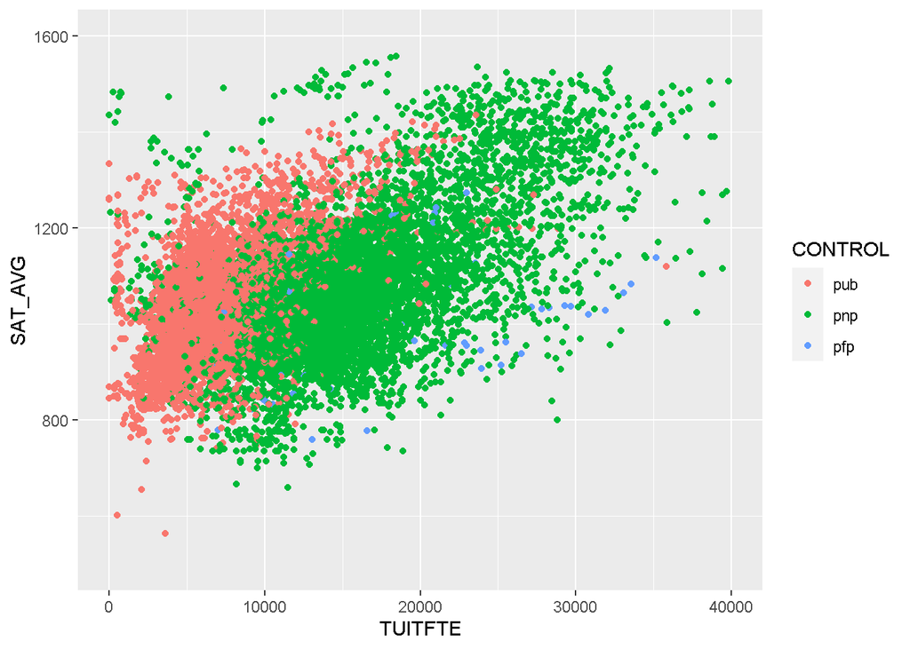

```r
library(ggplot2)
ggplot(scores.sub, aes(x = TUITFTE, y = SAT_AVG, color = CONTROL)) +
  geom_point() + xlim(0, 40000) + ylim(500, 1600)
```

Now tabulate the number of schools that have tuition per FTE over 20,000 and/or average SAT over 1200, grouped by ownership category. Your output should be sorted on the groupings you define, so the first row should be public, TUITFTE < 20,000 and SAT_AVG < 1200, and so on for 12 rows. See the Introduction vignette for data.table for insight on how to perform this operation. Hint: “sorted by” and “expressions in by”.

```r
scores.sub[, .N, keyby = .(CONTROL, TUITFTE > 20000, SAT_AVG > 1200)]
```

```
##     CONTROL TUITFTE SAT_AVG    N
##  1:     pub   FALSE   FALSE 4207
##  2:     pub   FALSE    TRUE  437
##  3:     pub    TRUE   FALSE   12
##  4:     pub    TRUE    TRUE   17
##  5:     pnp   FALSE   FALSE 5648
##  6:     pnp   FALSE    TRUE  411
##  7:     pnp    TRUE   FALSE  611
##  8:     pnp    TRUE    TRUE  853
##  9:     pfp   FALSE   FALSE   61
## 10:     pfp   FALSE    TRUE    2
## 11:     pfp    TRUE   FALSE   22
## 12:     pfp    TRUE    TRUE    4
```

# Question 3 - subsets of data

Use data.table to obtain the tuition per FTE and average SAT for the two schools with the top average SAT within each ownership group. Hint: I performed this in two steps, first by ordering `scores.sub`, and then using “subset of data”. Make sure to avoid returning all of the columns…

```r
sorted.score.sub <- scores.sub[order(CONTROL, -SAT_AVG)]
sorted.score.sub[, head(.SD, 2), by = CONTROL]
```

```
##    CONTROL TUITFTE SAT_AVG
## 1:     pub   23581    1436
## 2:     pub   19498    1422
## 3:     pnp   18456    1558
## 4:     pnp   18091    1555
## 5:     pfp   22998    1274
## 6:     pfp   21020    1242
```

# Question 4 - MovieLens sparse dataset

As we mentioned in class, one common form of sparse data is when we have information about individuals and their interaction with a large set of items (e.g. movies, products, etc.). The interactions may be ratings or purchases. One publicly available dataset of movie ratings is *MovieLens*, which has a 1 MB download available here:

https://grouplens.org/datasets/movielens/

Download the `ml-latest-small.zip` dataset. Take a look at each of the CSV files. How many of the movies have the “Comedy” genre attached to them?

```r
# import data
file <- "movies.csv"
movies <- fread(file)

# count the number of movies that have the "Comedy" genre attached
movies[, .N, grepl("Comedy", genres)]
```

```
##    grepl    N
## 1:  TRUE 3756
## 2: FALSE 5986
```

```r
# From the output, there are 3756 movies which have the "Comedy" genre attached.
```

Build a sparse matrix of the movies by users, and just put a 1 for if the user rated the movie (don’t actually record the value of the rating itself). You can do this by specifying `x=1`. In the abstract, this is a very large matrix, but this is because the user IDs go up to nearly 200,000. Remove the rows of the sparse matrix where there are no ratings to produce a sparse matrix that is roughly ~10,000 by ~600. Use `summary` to investigate the range, quartiles, etc. of number of movies rated by each user.

```r
# import data
file <- "ratings.csv"
ratings <- fread(file)

# create a sparse matrix
library(Matrix)
movies.by.users <- sparseMatrix(i = ratings$movieId, j = ratings$userId, x=1)
movies.by.users <- movies.by.users[(rowSums(movies.by.users)>0), ]

# investigate the range, quartiles, etc. of number of movies rated by users
summary(colSums(movies.by.users))
```

```
##    Min. 1st Qu.  Median    Mean 3rd Qu.    Max.
##    20.0    35.0    70.5   165.3   168.0  2698.0
```

There are multiple ways to compute the SVD of a sparse matrix. If after manipulating the matrix in its sparse form, it is not too large (as in this case), one can just run `svd` which will coerce the matrix into a dense one. Or there are special functions in packages which are designed to compute (potentially sparse) SVD solutions on sparse matrices. Two such functions are `sparsesvd::sparsesvd` and `irlba::ssvd`. You can choose any of these three methods, in either case you should specify to return only 3 left singular vectors (`nu=3`, `rank=3`, or `k=3`, respectively). For `ssvd` in the irlba package, you should specify that the number of nonzero components in the right singular vectors should be all (the number of rows of x), which will give a warning that you should ignore. All of these methods will produce roughly the same decomposition, with arbitrary sign changes on the singular vectors. The sparse versions are about 1000 times faster, as they do not coerce the matrix into a dense version.

Compute the SVD of the matrix using one of the methods above. Plot the columns of the U matrix against each other: 1 vs 2, 2 vs 3, 1 vs 3. Note that column 1 and 3 are correlated, with a long tail of movies. Investigate the names of these movies. What property can you infer about the top 6 movies in the tail w.r.t. column 1 and 3? Now look at the extremes of column 2 of U. What difference can you tell about the movies, between the smallest values and the largest values in column 2?

Hint: there are a few movies which are in the `movies.csv` file, but are not in the `ratings.csv` file. I recommend to subset the list of movies first, which will help with this problem.

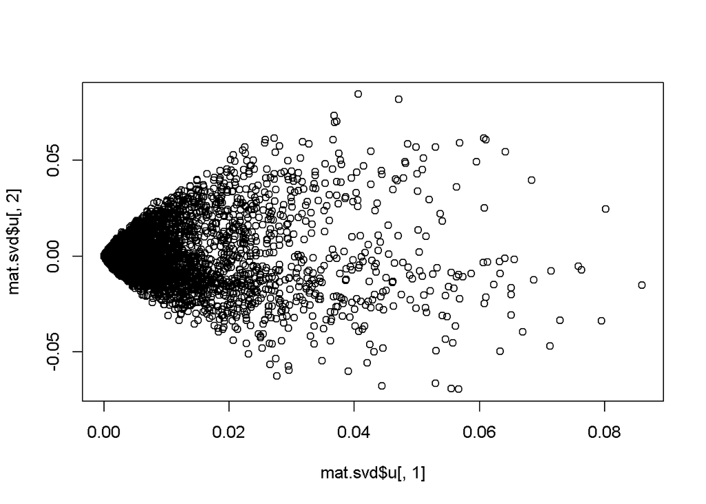

```r
# subset the list of movies
movies.subset <- movies[(movies$movieId %in% ratings$movieId), ]

# compute the SVD of the matrix
library(sparsesvd)
mat.svd <- sparsesvd(movies.by.users, rank = 3)

# plot the columns of the U matrix against each other
plot(mat.svd$u[,1], mat.svd$u[,2])
```

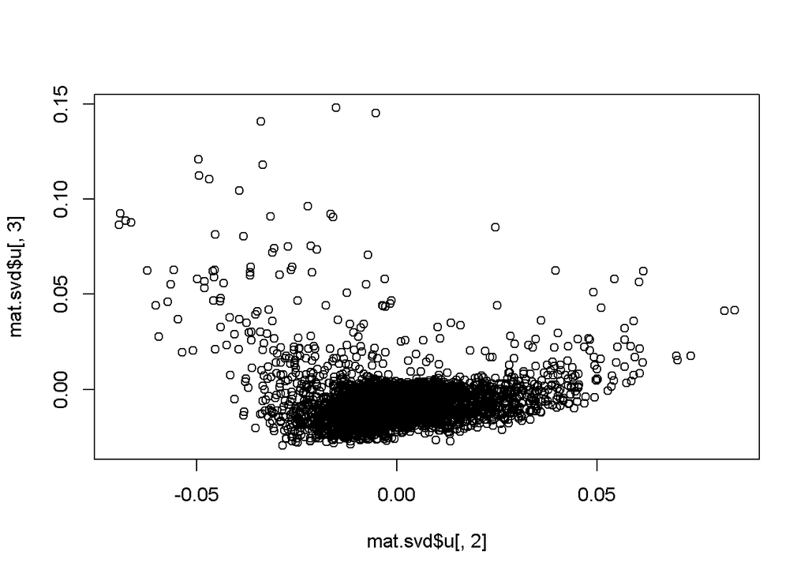

```r
plot(mat.svd$u[,2], mat.svd$u[,3])
```

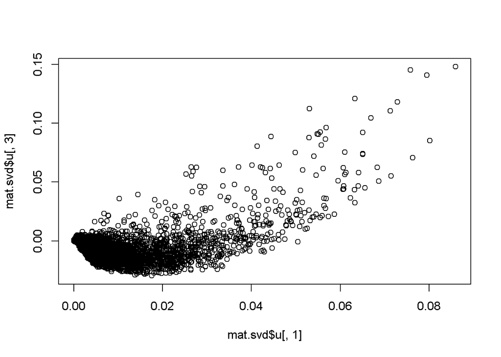

```r
plot(mat.svd$u[,1], mat.svd$u[,3])
```

```r
# names of the movies on the tail w.r.t. column 1 and 3
tail.1.3 <- scale(mat.svd$u[,1]) + scale(mat.svd$u[,3])
whichpart <- function(x, n=30) {
  nx <- length(x)
  p <- nx-n
  xp <- sort(x, partial=p)[p]
  which(x > xp)
}
movies.subset[whichpart(tail.1.3,6), ]
```

```
##    movieId                            title                           genres
## 1:     110                Braveheart (1995)                 Action|Drama|War
## 2:     296              Pulp Fiction (1994)      Comedy|Crime|Drama|Thriller
## 3:     318 Shawshank Redemption, The (1994)                      Crime|Drama
## 4:     356              Forrest Gump (1994)         Comedy|Drama|Romance|War
## 5:     480             Jurassic Park (1993) Action|Adventure|Sci-Fi|Thriller
## 6:     593 Silence of the Lambs, The (1991)            Crime|Horror|Thriller
```

In this question, the movies in the tail w.r.t. column 1 and 3 are identified by taking the summation of the corresponding standardized values of column 1 and 3. The six movies with the greatest values of the summation are identified as above. One property shared by the movies identified is that they are all very famous movies rated by a lot of people.

```r
# smallest values in column 2
movies.subset[whichpart((-mat.svd$u[,2]),8), ]
```

```
##    movieId                           title
## 1:      21               Get Shorty (1995)
## 2:     329   Star Trek: Generations (1994)
## 3:     349 Clear and Present Danger (1994)
## 4:     380                True Lies (1994)
## 5:     457            Fugitive, The (1993)
## 6:     587                    Ghost (1990)
## 7:     590       Dances with Wolves (1990)
## 8:     592                   Batman (1989)
##                                      genres
## 1:                    Comedy|Crime|Thriller
## 2:                   Adventure|Drama|Sci-Fi
## 3:              Action|Crime|Drama|Thriller
## 4: Action|Adventure|Comedy|Romance|Thriller
## 5:                                 Thriller
## 6:    Comedy|Drama|Fantasy|Romance|Thriller
## 7:                  Adventure|Drama|Western
## 8:                    Action|Crime|Thriller
```

```r
# largest values in column 2
movies.subset[whichpart(mat.svd$u[,2],8), ]
```

```
##    movieId                                                 title
## 1:    7153 Lord of the Rings: The Return of the King, The (2003)
## 2:   58559                               Dark Knight, The (2008)
## 3:   59315                                       Iron Man (2008)
## 4:   60069                                        WALLÂ·E (2008)
## 5:   68954                                             Up (2009)
## 6:   72998                                         Avatar (2009)
## 7:   79132                                      Inception (2010)
## 8:   91529                         Dark Knight Rises, The (2012)
##                                             genres
## 1:                  Action|Adventure|Drama|Fantasy
## 2:                         Action|Crime|Drama|IMAX
## 3:                         Action|Adventure|Sci-Fi
## 4:     Adventure|Animation|Children|Romance|Sci-Fi
## 5:              Adventure|Animation|Children|Drama
## 6:                    Action|Adventure|Sci-Fi|IMAX
## 7: Action|Crime|Drama|Mystery|Sci-Fi|Thriller|IMAX
## 8:                     Action|Adventure|Crime|IMAX
```

From the output above, the movies with the smallest values in column 2 have mostly been released during the 1990s, whereas the movies with the largest values in column 2 have mostly been released during the 2000s.